# Data Visualization in R with Tidyverse

By Mark Hand For Varun Rai’s Statistical Learning Class, Spring 2019

## First things first:

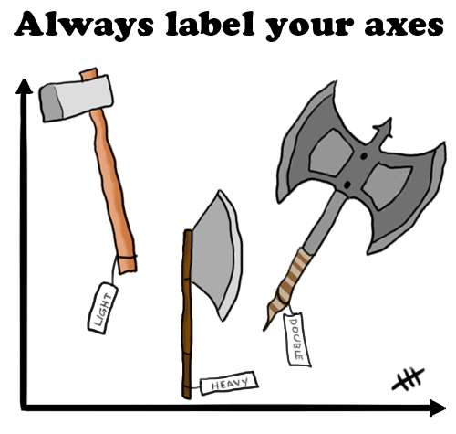

…unless you can get away with it.

Welcome to Data Visualization in R! We’ll be using a dataset from the Pew Research Center’s [Forum on Religion & Public Life](http://www.pewforum.org/), a country-wide survey from 2014 Americans’ religious beliefs. You can download the data [from Pew](http://www.pewforum.org/datasets/) or my [GitHub page](https://github.com/markchand/Religion-in-America) (sorry Pew!).

## Importing data

Importing data looks like this:

```r
library(haven)
pew <- read_sav("Pew-Research-Center-2014-U.S.-Religious-Landscape-Study/Dataset - Pew Research Center 2014 Religious Landscape Study National Telephone Survey - Version 1.1 - December 1 2016.sav")
```

To visualize this data we will be using a package called ggplot2, which is included in a package of packages called *tidyverse*:

```r
library(tidyverse)
```

## A roadmap for today (and some conceptual stuff)

While we’re all getting set up, here’s a roadmap for the afternoon:

- R and plot() versus tidyverse and ggplot2
- ggplot and the grammar of graphics
- Principles of pretty visualizations
- Getting data into shape with dplyr
- Using ggplot to examine your data

## Getting to know your data

The Pew data comes with a codebook from which we’ll pick out a few variables to work with. If you want to see some information about the variables at once, you *could* do some of these things:

```r
summary(pew)
pairs(pew)
corr(pew)
```

… but you don’t want to do any of those things in a dataset with this many variables. You can check out the names and basic structure of a dataset with `str()`.

```r
str(pew)
# A quick note here: eval=FALSE will prevent the code chunk from providing any output into your markdown document.
```

## Charts and things

Let’s start with the basics: a histogram of religious affiliation, the simplest version of this is the variable “RELTRAD.”

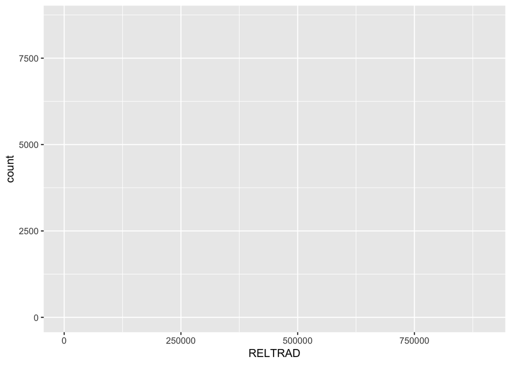

```r
ggplot(pew, aes(RELTRAD)) + geom_bar()
```

That didn’t work! Why not? This a pretty normal mistake that I regularly make: The data I want to use is stored as integers rather than text (characters), and different `geoms` require different kinds of data. If we look at the data in the codebook, we also see that the data is in a format unhelpful to our visualization. We need to use the codebook to transform the data into something useful, using the `mutate` and `case_when` commands from dplyr, another package in the tidyverse.

```r
pew %>%
  mutate(
    RELTRAD2 = case_when(
  RELTRAD == 1100 ~ "Evangelical Protestant Tradition",
  RELTRAD == 1200 ~ "Mainline Protestant Tradition",
  RELTRAD == 1300 ~ "Historically Black Protestant Tradition",
  RELTRAD == 10000 ~ "Catholic",
  RELTRAD == 20000 ~ "Mormon",
  RELTRAD == 30000 ~ "Orthodox Christian",
  RELTRAD == 40001 ~ "Jehovah's Witness",
  RELTRAD == 40002 ~ "Other Christian",
  RELTRAD == 50000 ~ "Jewish",
  RELTRAD == 60000 ~ "Muslim",
  RELTRAD == 70000 ~ "Buddhist",
  RELTRAD == 80000 ~ "Hindu",
  RELTRAD == 90001 ~ "Other World Religions",
  RELTRAD == 90002 ~ "Other Faiths",
  RELTRAD == 100000 ~ "Unaffiliated (religious 'nones')",
  RELTRAD == 900000 ~ "Don't know/refused - no information on religious identity")) -> pew
```

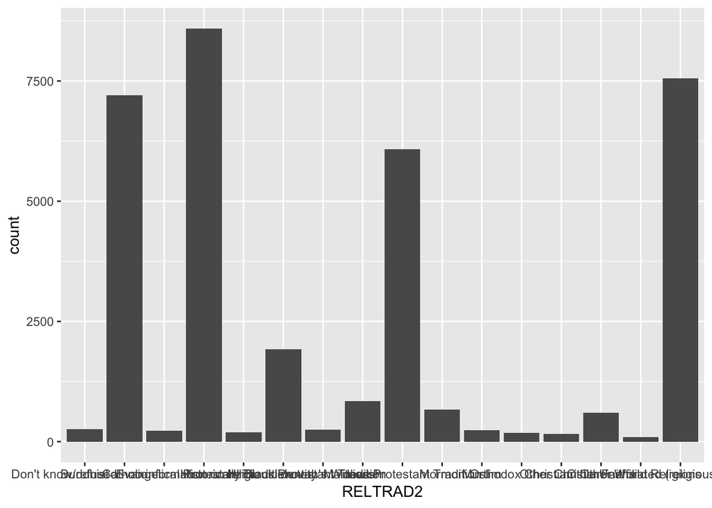

```r
ggplot(pew, aes(RELTRAD2)) + geom_bar()
```

That’s still pretty terrible looking. We want to do something like this:

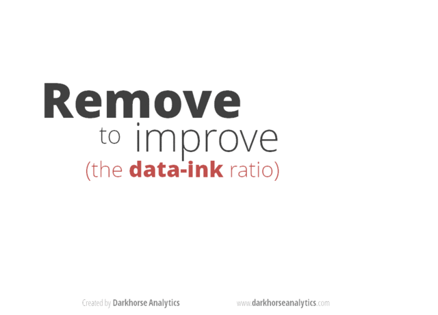

Let’s clean our plot up with code options from ggplot. Run the code below in stages: After `geom_bar()`, highlight one additional row every time you rune the code to watch what happens.

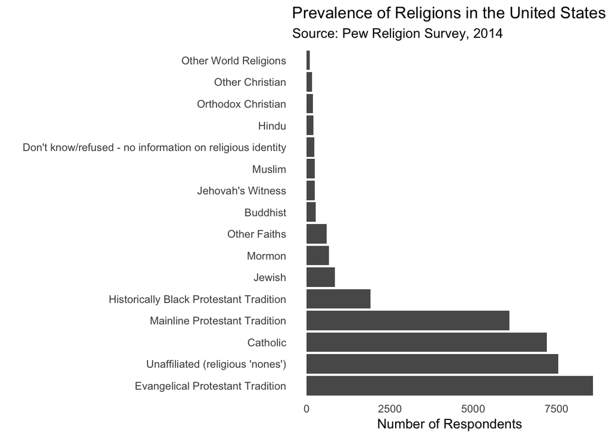

```r
ggplot(pew, aes(x = fct_infreq(RELTRAD2))) +
  geom_bar() +
  coord_flip() +
  theme_minimal() +
  labs(y="Number of Respondents", x="") +
  ggtitle( "Prevalence of Religions in the United States", subtitle = "Source: Pew Religion Survey, 2014") +
  theme(panel.grid.major = element_blank(), panel.grid.minor = element_blank())
```

Better! Let’s try another one. We know now that we’ll need to do some mutating in order to take a look at the relationship between age and ideology in the survey:

```r
pew %>%
  mutate(
    agerec2 = case_when(
  agerec == 1 ~ "Age 24 or younger",
  agerec == 2 ~ "Age 25-29",
  agerec == 3 ~ "30-34",
  agerec == 4 ~ "35-39",
  agerec == 5 ~ "40-44",
  agerec == 6 ~ "45-49",
  agerec == 7 ~ "50-54",
  agerec == 8 ~ "55-59",
  agerec == 9 ~ "60-64",
  agerec == 10 ~ "65-69",
  agerec == 11 ~ "70-74",
  agerec == 12 ~ "75-79",
  agerec == 13 ~ "80-84",
  agerec == 14 ~ "85-89",
  agerec == 15 ~ "Age 90 or older",
  agerec == 99 ~ "NA")
  ) -> pew
```

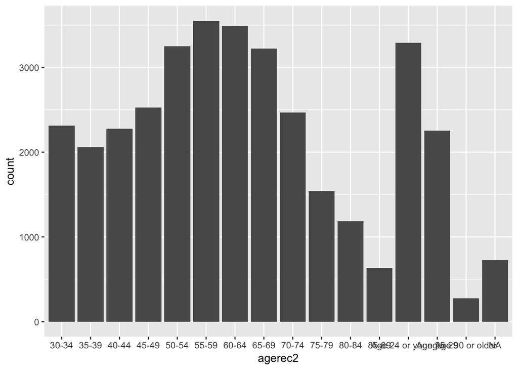

```r
ggplot(pew, aes(agerec2)) + geom_bar()
```

Not cool. Let’s clean things up a bit and plot again:

```r
pew %>%
  mutate(
    agerec2 = case_when(
  agerec == 1 ~ "24 or younger",
  agerec == 2 ~ "25-29",
  agerec == 3 ~ "30-34",
  agerec == 4 ~ "35-39",
  agerec == 5 ~ "40-44",
  agerec == 6 ~ "45-49",
  agerec == 7 ~ "50-54",
  agerec == 8 ~ "55-59",
  agerec == 9 ~ "60-64",
  agerec == 10 ~ "65-69",
  agerec == 11 ~ "70-74",
  agerec == 12 ~ "75-79",
  agerec == 13 ~ "80-84",
  agerec == 14 ~ "85-89",
  agerec == 15 ~ "90 or older",
  agerec == 99 ~ "NA"),
    ideo2 = case_when(
  ideo == 1 ~ "1 - Very conservative",
    ideo == 2 ~ "2 - Conservative",
    ideo == 3 ~ "3 - Moderate",
    ideo == 4 ~ "4 - Liberal",
    ideo == 5 ~ "5 - Very liberal",
    ideo == 9 ~ "NA")) -> pew
```

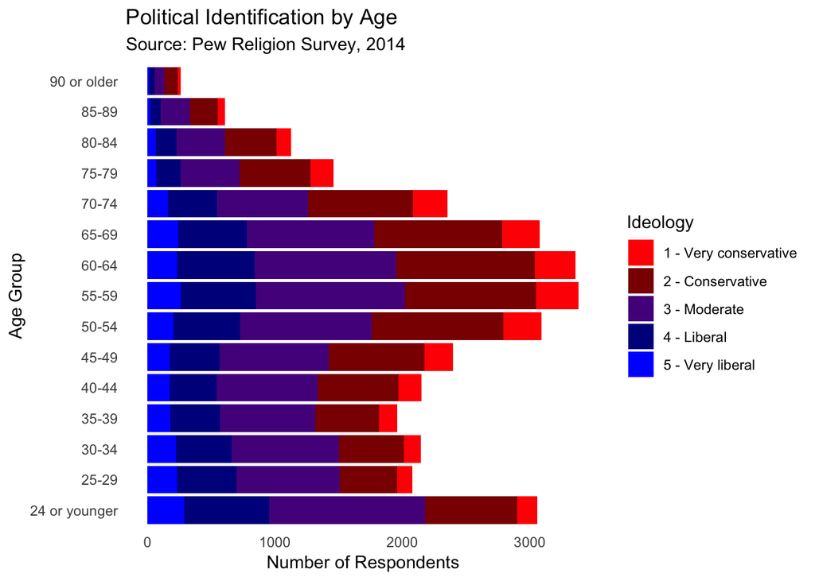

```r
ggplot(subset(pew, agerec2!="NA" & ideo2!="NA"), aes(agerec2, fill = ideo2)) +
  geom_bar() +
  coord_flip() +
  theme_minimal() +
  labs(y="Number of Respondents", x="Age Group", fill="Ideology") +
  ggtitle( "Political Identification by Age", subtitle = "Source: Pew Religion Survey, 2014") +
  theme(panel.grid.major = element_blank(), panel.grid.minor = element_blank()) +
  scale_fill_manual(breaks = c("1 - Very conservative", "2 - Conservative", "3 - Moderate","4 - Liberal","5 - Very liberal"), values=c("red","dark red","purple4","dark blue","blue"))
```

Now we’re getting somewhere!

## Animated graphics with ggplot and gganimate

Now, just for kicks: When I’m well-caffeinated, I always take a first stab at *one* thing that I’d like to learn how to do but don’t understand yet. This time I wanted to try gganimate:

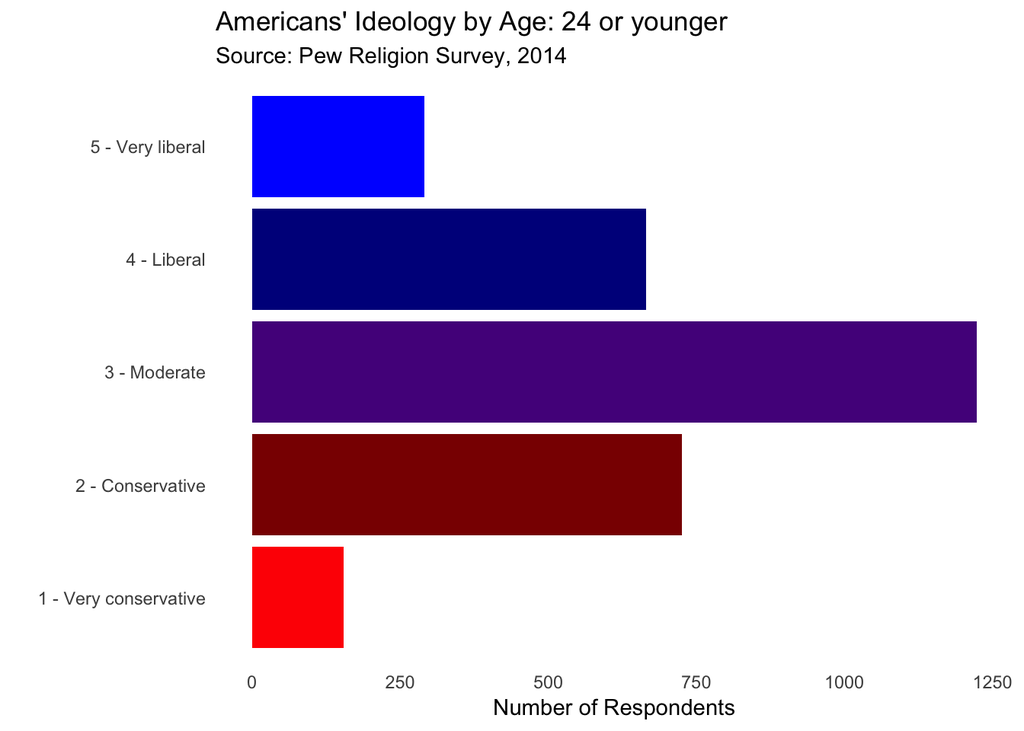

```r
library(gganimate)
p <- ggplot(subset(pew, agerec2!="NA" & ideo2!="NA"), aes(ideo2, fill = ideo2)) +
  geom_bar() +
  coord_flip() +
  theme_minimal() +
  theme(panel.grid.major = element_blank(), panel.grid.minor = element_blank()) +
  labs(y="Number of Respondents", x="") +
  ggtitle( "Political Identification by Age", subtitle = "Source: Pew Religion Survey, 2014")  +
  scale_fill_manual(breaks = c("1 - Very conservative", "2 - Conservative", "3 - Moderate","4 - Liberal","5 - Very liberal"), values=c("red","dark red","purple4","dark blue","blue")) + theme(legend.position="none")

p + transition_states(agerec2) +
  labs(title = "Americans' Ideology by Age: {closest_state}")
```

## Some other (R)esouces

More on ggplot and tidyverse:

- DataCamp/Data Visualization with ggplot2 (part 2).Rmd
- [Interactive visualizations with R - a minireview](http://ouzor.github.io/blog/2014/11/21/interactive-visualizations.html)
- [Data visualization with ggplot2](https://datacarpentry.org/R-ecology-lesson/04-visualization-ggplot2.html)

Just **some** of the things I had to search for:

- [Data Wrangling Part 2: Transforming your columns into the right shape](https://suzan.rbind.io/2018/02/dplyr-tutorial-2/)
- [R for Data Science](https://r4ds.had.co.nz)
- [R Color Cheatsheet](https://www.nceas.ucsb.edu/~frazier/RSpatialGuides/colorPaletteCheatsheet.pdf)
- [ggplot2 colors : How to change colors automatically and manually?](http://www.sthda.com/english/wiki/ggplot2-colors-how-to-change-colors-automatically-and-manually)
- [Help needed with simple animation](https://github.com/thomasp85/gganimate/issues/94)

As usual, a massive thanks to [Matt Worthington](https://www.linkedin.com/in/mattworthington) for all his help.